# Entrega 4

# 1.Objetivo del reporte

La problemática de pobreza extrema a nivel provincial abordada en este trabajo implica la consideración de ciertas variables independientes que contribuyen a la explicación del tema elegido en el propósito de examinar mediante tecnicas cuantitativas el grado de relación o influencia de las VI’s seleccionadas, desde base de datos nacionales actualizadas, para detallar principales elementos explicativos del problema socioeconómico mencionado. Por ello, la elección de técnicas idóneas para coadyuvar a este proceso examinador resultan cruciales en el analisis del problema: la utilización de una regresión lineal múltiple permitió, en primera instancia, la construcción de un modelo adecuado que represente adecuadamente el comportamiento de la problematica de pobreza extrema en función con las VI’s escogidas:acceso a recursos hídricos, internet, electricidad, entre otros. Asimismo, la ejecución de un análisis factorial exploratorio permitirá identificar estructuras subyacentes y factores latentes donde la selección de variables esenciales, en contraste con el trabajo de una mayor cantidad de las mismas, posibilita la intepretación de los resultados mostrados. Debido al caso de estudio elegido, la problemática de pobreza extrema, resulta viable utilizar este tipo de técnica ante la gran variedad de variables que inciden en la explicación de este problema: acceso educativo, desnutrición, acceso al internet, líneas telefónicas, etc. En consecuencia, reducir este considerable numero de variables en aquellas que posean un mayor grado de explicabilidad y organizarlas en factores para determinar su incidencia de asociación con estos permitirán una adecuada visualización de las variables con mayor importancia y, por ende, contribuir a la generación de nuevas hipótesis en beneficios de la situación estudiada.

# 2.Construcción de las bases de datos

La estructuración de la base de datos ha implicado la consideración de fuentes cuantitativas de instituciones relacionadas a la formulación de políticas públicas y el desarrollo nacional. En primer lugar, se utilizó información recopilada a través de la CEPLAN (Centro de Planeamiento Estratégico Nacional), dentro del cual rescatamos las siguientes variables:

-Porcentaje de acceso al agua de acuerdo a red pública -Porcentaje de la cantidad de viviendas de material durable -Porcentaje de acceso a los servicios públicos en zonas rurales -Procentaje de desnutrición crónica de niños -Frecuencia de patrullaje integrado con la PNP -Frecuencia de recojo de residuos solidos.

Por otro lado, se optó por utilizar la página web “datosabiertos.gob.pe” para encontrar data actualizada en torno a otras variables explicativas del problema en estudios. En efecto, se empleó la data del INEI 2021 para seleccionar ciertos elementos que contribuyen a la justificación de la pobreza extrema en estudio.

-Número de computadoras con acceso a internet -Canales de atención al ciudadano -Cantidad de grupos electrógenos -Frecuencia de patrullaje integrado con la PNP -Número de lineas de telefonia fiija segun municipalidad -Porcentaje de escuelas que cuentan con acceso a internet (primaria)

- Se utilizaron las variables en un nivel provincial para evidenciar la problematica de pobreza extrema desde una óptica de subdivisión administrativa inferior a un departamento y diferente de la perspectiva distrital.

Con las variable recopiladas se procedió a reunirlas en una base de datos general creada en excel con el propósito de facilitar su uso en las posteriores tecnicas o pruebas cuantitativas previstas para analizar la problemática de pobreza extrema en R. Por ello, se utilizaron metodos de limpieza de datos y merge para efectuar un orden adecuado entre las variables que permitan un trabajo correcto con ellas en el programa de R.

Creemos que están variables están muy relacionadas con el problema de pobreza extrema que un 5% de la población peruana experimenta acorde con la información del INEI(2021). En ese sentido, nuestra base de datos fue creada en función a los servicios básicos que una persona debe contar para poser una calidad de vida deseada y evitar la condición socioeconómica de pobre extremo.

# 3. Modelo de regresión

```r
library(xfun)
library(rmdformats)
library(rio)
library(readxl)
library(dplyr)
library(ggplot2)
library(GGally)
library(Hmisc)
library(corrplot)
library(PerformanceAnalytics)
library(Rmisc)
library(psych)
data=import("https://docs.google.com/spreadsheets/d/1AfdMUBBIYEdnT4bwUVK3r-Uxvy7FUhtjkczcR1rqIEs/edit#gid=1279435937")
```

```r
data1 <- subset(data, select = -c(1, 2))
```

**analisis de correlación total**

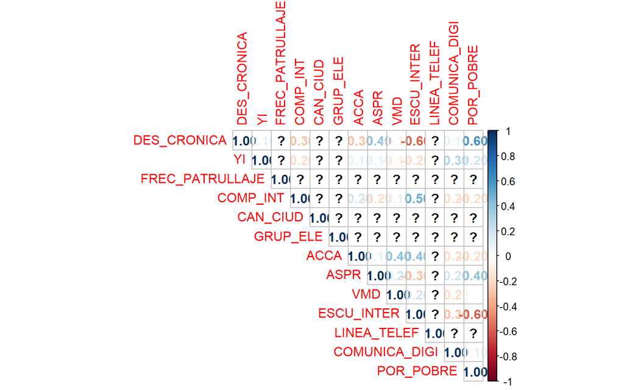

```r
correlacion<-round(cor(data1), 1)

corrplot(correlacion, method="number", type="upper")
```

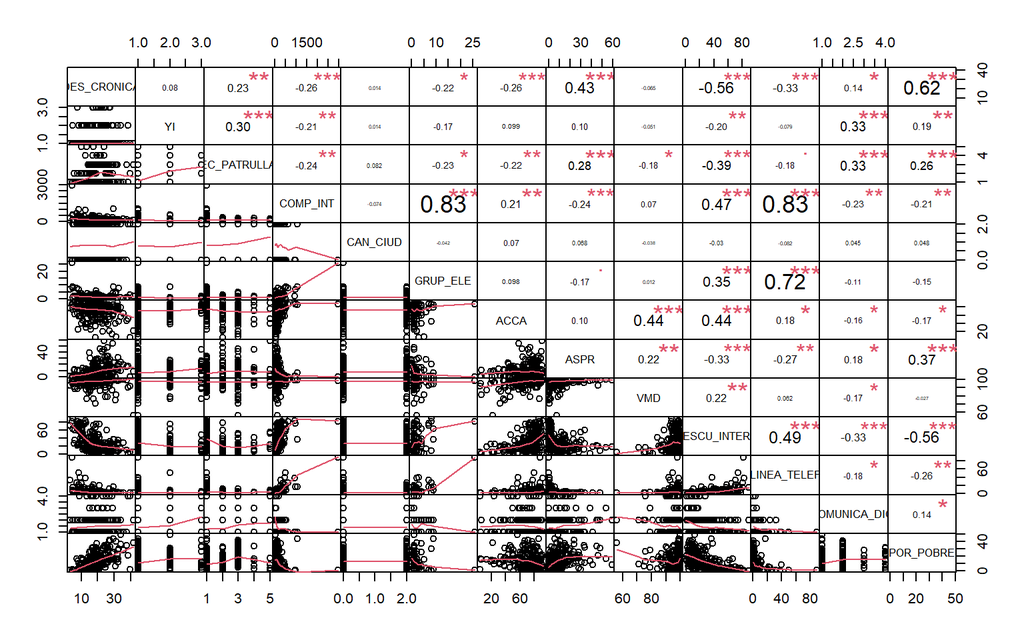

```r
chart.Correlation(data1, histogram = F, pch = 19)
```

**modelo de regresión lineal múltiple**

MODELO 1

```r
modelo1<-lm(POR_POBRE~YI + FREC_PATRULLAJE + COMP_INT + ASPR + LINEA_TELEF + COMUNICA_DIGI + ACCA, data1)

summary(modelo1)
```

```
##
## Call:
## lm(formula = POR_POBRE ~ YI + FREC_PATRULLAJE + COMP_INT + ASPR +
##     LINEA_TELEF + COMUNICA_DIGI + ACCA, data = data1)
##
## Residuals:
##     Min      1Q  Median      3Q     Max
## -15.116  -5.319  -1.329   4.237  30.849
##
## Coefficients:
##                  Estimate Std. Error t value Pr(>|t|)
## (Intercept)     24.683505   4.630948   5.330 5.14e-07 ***
## YI              -0.159364   1.759499  -0.091   0.9280
## FREC_PATRULLAJE  0.618017   0.877390   0.704   0.4827
## COMP_INT         0.009656   0.004603   2.098   0.0382 *
## ASPR             0.392282   0.089329   4.391 2.57e-05 ***
## LINEA_TELEF     -0.304033   0.124310  -2.446   0.0160 *
## COMUNICA_DIGI   -2.007892   1.271947  -1.579   0.1172
## ACCA            -0.213366   0.050083  -4.260 4.27e-05 ***
## ---
## Signif. codes:  0 '***' 0.001 '**' 0.01 '*' 0.05 '.' 0.1 ' ' 1
##
## Residual standard error: 8.377 on 112 degrees of freedom
##   (76 observations deleted due to missingness)
## Multiple R-squared:  0.2998, Adjusted R-squared:  0.2561
## F-statistic: 6.851 on 7 and 112 DF,  p-value: 8.934e-07
```

A continuacion, haremos el diagnóstico al modelo seleccionado.

Diagnósticos de la regresión

1. **Linealidad**

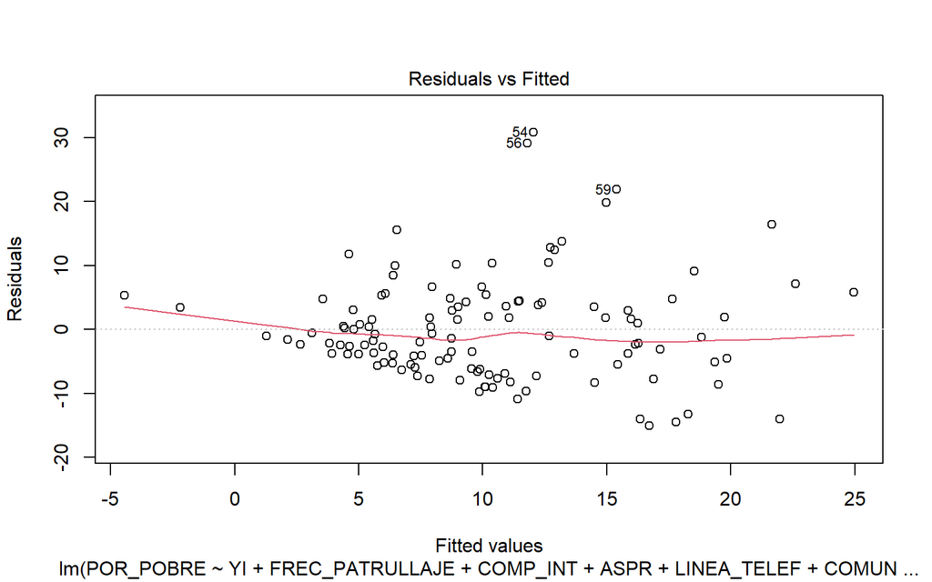

```r
plot(modelo1,1)
```

```r
mean(modelo1$residuals)
```

```
## [1] 7.437627e-17
```

Respecto al gráfico mostrado, resulta posible evidenciar que el modelo tiende a ser lineal pese a que la parte inicial empieza con una ligera curvatura de su posición esperada. Asimismo,con el resultado obtenido por las medias residuales dicha afirmación resulta válida para efectos explicativos en el diagnóstico de linealidad observada.

2.**Homocedasticidad**

```r
library(lmtest)
```

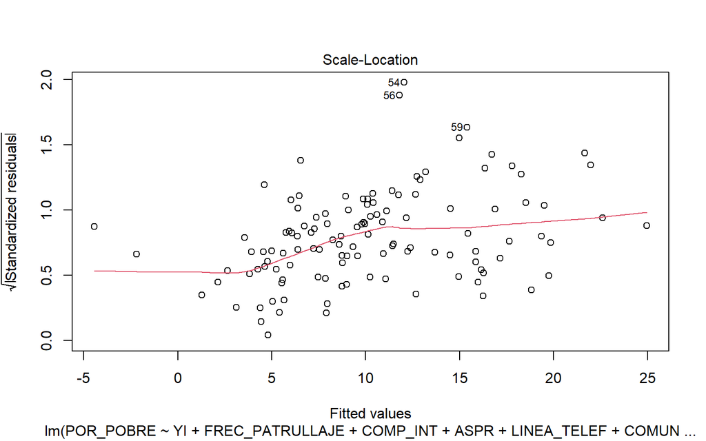

```r
library(kableExtra)
plot(modelo1, 3)
```

```r
resBP=bptest(modelo1)
data.frame(list('BP'=resBP$statistic,
             'df'=resBP$parameter,
             "p-value"=resBP$p.value))%>%
    kable(caption = resBP$method)%>%kable_styling(full_width = F)
```

studentized Breusch-Pagan test

|  | BP | df | p.value |
| --- | --- | --- | --- |
| BP | 11.7953 | 7 | 0.1074946 |

3. **Normalidad de los residuos**

```r
library(kableExtra)
```

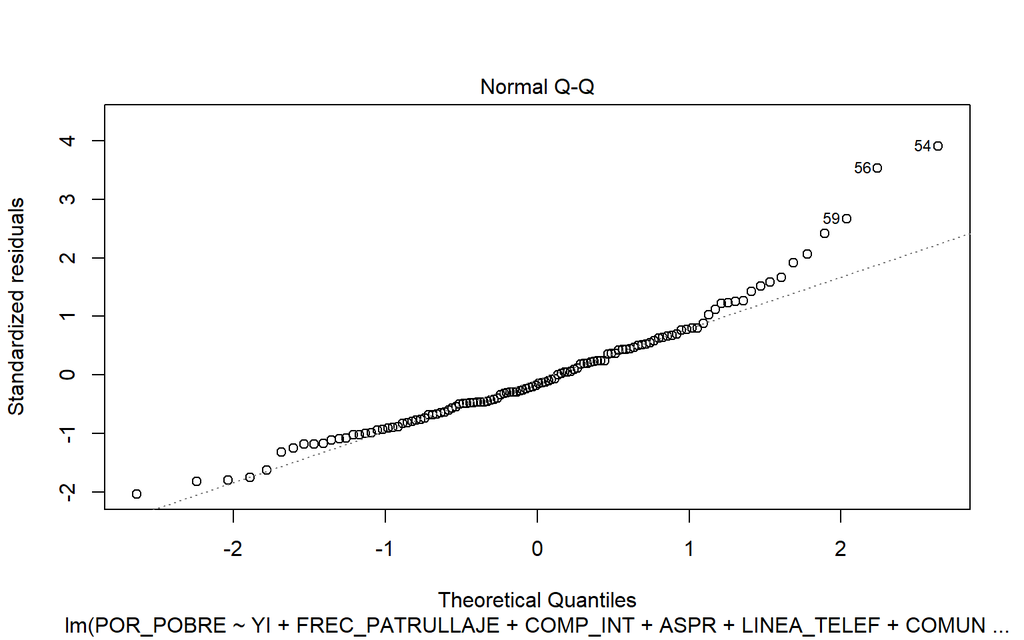

```r
plot(modelo1, 2)
```

```r
resSW=shapiro.test(modelo1$residuals)
data.frame(list('SW'=resSW$statistic,
             "p-value"=resSW$p.value))%>%
    kable(caption = resSW$method)%>%kable_styling(full_width = F)
```

Shapiro-Wilk normality test

|  | SW | p.value |
| --- | --- | --- |
| W | 0.9375649 | 2.94e-05 |

El test de Shapiro nos muestra que el p-value resulta menor a 0.05: los residuos de la data no se distribuyen de forma normal. Las distancias entre los valores observados y esperados no se reparten de manera adecuada.

4. **No multicolinealidad**

```r
library(DescTools)
library(kableExtra)
```

```r
VIF(modelo1) %>%kable(col.names = "VIF",caption ="Evaluando Multicolinealidad usando VIF (Variance Inflation Factors)" )%>%kable_styling(full_width = F)
```

Evaluando Multicolinealidad usando VIF (Variance Inflation Factors)

|  | VIF |
| --- | --- |
| YI | 1.117297 |
| FREC_PATRULLAJE | 1.182529 |
| COMP_INT | 3.433450 |
| ASPR | 1.172874 |
| LINEA_TELEF | 3.381687 |
| COMUNICA_DIGI | 1.278826 |
| ACCA | 1.248037 |

Conforme con la data producida, se asegura la ausencia de variables independientes fuertemente correlacionadas que perjudiquen la medición de nuestro modelo. La prueba VIF efectuada muestra valores menores a cinco que nos permiten evitar medir una variable independiente dos veces y ,de esa forma, no confundir al modelo planteado.

5.**valores influyentes**

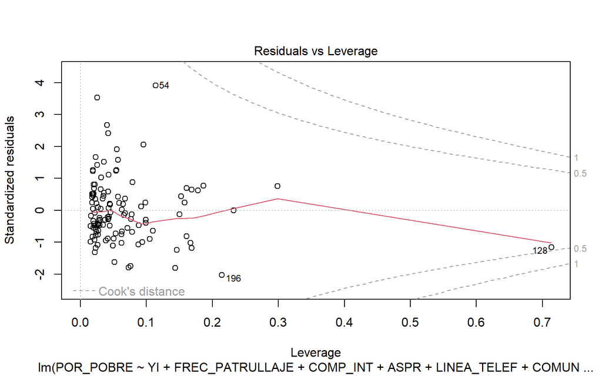

```r
plot(modelo1, 5)
```

```r
checkReg2=as.data.frame(influence.measures(modelo1)$is.inf)
checkReg2[checkReg2$cook.d & checkReg2$hat,c('cook.d','hat')]%>%kable(caption = "Valores Influyentes criticos")%>%kable_styling(full_width = F)
```

Valores Influyentes criticos

| cook.d | hat |
| --- | --- |

Conforme con los resultados expuestos, es posible afirmar que NO EXISTEN CASOS QUE AFECTEN A LOS CALCULOS DE LA REGRESIÓN PLANTEADA. Ello se puede evidenciar en la ausencia de filas observadas en el índice de Cook producido.

**Conclusión de la regresión lineal múltiple**

En conclusión, el modelo seleccionado presenta un R cuadrado ajustado del 0.2561 que nos brinda una explicación aceptable en torno a la problemática de la pobreza extrema que se pretende explicar con las distintas variables independientes usadas dentro del modelo propuesto. En adición, el p-value evidenciado nos muestra la validación del modelo establecido al ser menor a 0.05.

# 4. Análisis factorial exploratorio

**Repositorio de base de datos**

https://docs.google.com/spreadsheets/d/1AfdMUBBIYEdnT4bwUVK3r-Uxvy7FUhtjkczcR1rqIEs/edit#gid=1279435937

Instalación de paquetes necesarios para la AFE e importación de la base de datos utilizada

**Preprocesamiento (Formateo de variables)**

Eliminación de columnas con variables categóricas o con caracteres del alfabeto español: creación de nuevo objeto con la data modificada.

```r
data1 <- subset(data, select = -c(1, 2,7,8))
```

Conversión a numéricas de las variables restantes

```r
data1$POR_POBRE=as.numeric(data1$POR_POBRE)
data1$DES_CRONICA=as.numeric(data1$DES_CRONICA)
data1$ESCU_INTER=as.numeric(data1$ESCU_INTER)
data1$COMP_INT=as.numeric(data1$COMP_INT)
data1$ACCA=as.numeric(data1$ACCA)
data1$ASPR=as.numeric(data1$ASPR)
data1$VMD=as.numeric(data1$VMD)
data1$LINEA_TELEF=as.numeric(data1$LINEA_TELEF)
data1$FREC_PATRULLAJE=as.numeric(data1$FREC_PATRULLAJE)
data1$YI=as.numeric(data1$YI)
data1$COMUNICA_DIGI =as.numeric(data1$COMUNICA_DIGI)
```

Eliminación de los NAs que dificultan el proceso de la técnica a utilizar

```r
data1<- na.omit(data1)
```

**Análisis factorial exploratorio**

Cálculo de matriz de correlación

```r
library(polycor)
corMatrix=polycor::hetcor(data1)$correlations
```

Matriz de correlación de forma gráfica.

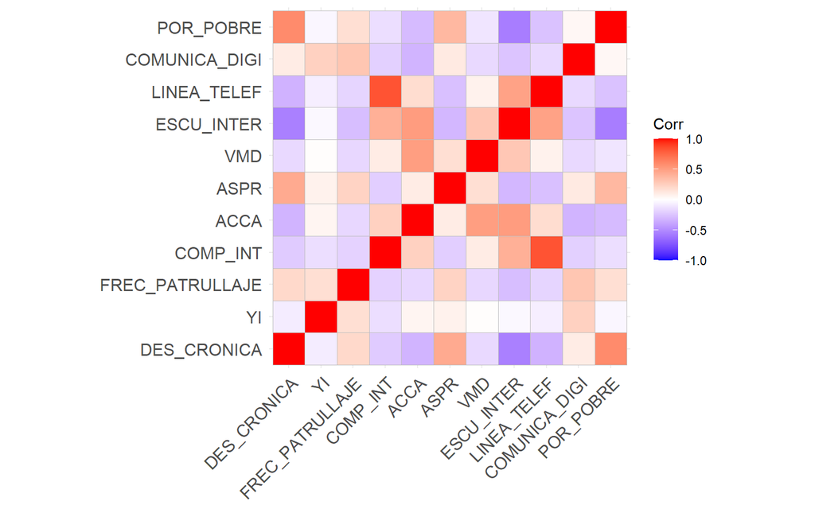

```r
library(ggcorrplot)

ggcorrplot(corMatrix)
```

De acuero al gráfico mostrado, existe un notable grado de correlación entre las variables principalmente aquellas que se relacionan en la diagonal central del gráfico. No obstante, resulta necesario reconocer que existen numerosas correlaciones que poseen un vínculo bastante reducido que podría afectar la AFE y una intepretación adecuada de los resultados a obtener.

```r
fa.parallel(data1, fa = 'fa',correct = T,plot = F)
```

```
## Parallel analysis suggests that the number of factors =  4  and the number of components =  NA
```

Redimensionamiento del número de factores con el grado de incidencia de cada variable en ellos (loadings).

```r
library(GPArotation)
resfa <- fa(data1,
            nfactors = 4,
            cor = 'mixed',
            rotate = "varimax",
            fm="minres")
print(resfa$loadings)
```

```
##
## Loadings:
##                 MR3    MR1    MR2    MR4
## DES_CRONICA      0.773 -0.139 -0.176
## YI              -0.109 -0.103         0.612
## FREC_PATRULLAJE  0.276        -0.163  0.620
## COMP_INT        -0.104  0.876  0.103 -0.206
## ACCA            -0.197  0.108  0.872
## ASPR             0.598 -0.133  0.308  0.266
## VMD                            0.575
## ESCU_INTER      -0.602  0.318  0.409 -0.170
## LINEA_TELEF     -0.259  0.891
## COMUNICA_DIGI          -0.123 -0.335  0.561
## POR_POBRE        0.720        -0.157
##
##                  MR3   MR1   MR2   MR4
## SS loadings    2.046 1.750 1.570 1.239
## Proportion Var 0.186 0.159 0.143 0.113
## Cumulative Var 0.186 0.345 0.488 0.600
```

Se procede a mejorar los resultados obtenido como consecuencia de haber obtenido más de un factor.

```r
print(resfa$loadings,cutoff = 0.5)
```

```
##
## Loadings:
##                 MR3    MR1    MR2    MR4
## DES_CRONICA      0.773
## YI                                    0.612
## FREC_PATRULLAJE                       0.620
## COMP_INT                0.876
## ACCA                           0.872
## ASPR             0.598
## VMD                            0.575
## ESCU_INTER      -0.602
## LINEA_TELEF             0.891
## COMUNICA_DIGI                         0.561
## POR_POBRE        0.720
##
##                  MR3   MR1   MR2   MR4
## SS loadings    2.046 1.750 1.570 1.239
## Proportion Var 0.186 0.159 0.143 0.113
## Cumulative Var 0.186 0.345 0.488 0.600
```

Por último, se proceden a visualizar, de forma gráfica, la incidencia de las variables en los factore establecidos.

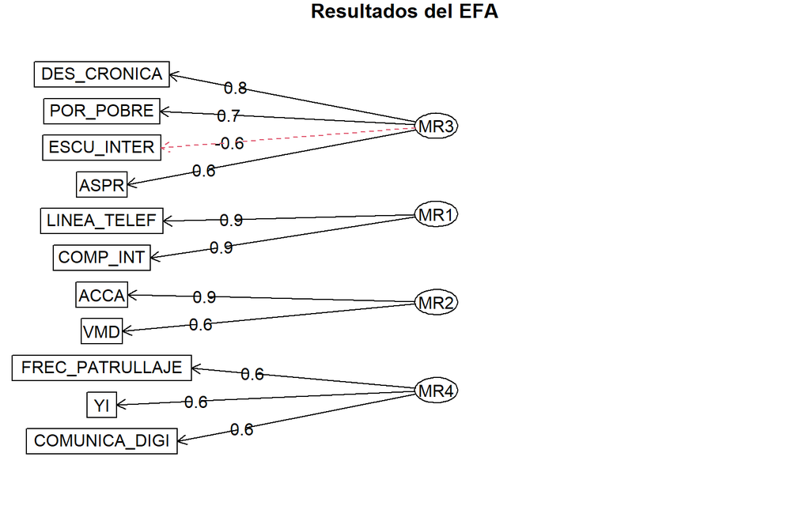

```r
fa.diagram(resfa,main = "Resultados del EFA")
```

```r
sort(resfa$communality)
```

```
##             VMD              YI   COMUNICA_DIGI FREC_PATRULLAJE            ASPR
##       0.3401439       0.4058242       0.4474408       0.4945630       0.5406711
##       POR_POBRE     DES_CRONICA      ESCU_INTER            ACCA        COMP_INT
##       0.5489954       0.6476179       0.6589304       0.8165681       0.8321496
##     LINEA_TELEF
##       0.8717431
```

```r
sort(resfa$complexity)
```

```
##             VMD       POR_POBRE            ACCA        COMP_INT              YI
##        1.055449        1.119052        1.147933        1.169581        1.171413
##     DES_CRONICA     LINEA_TELEF FREC_PATRULLAJE   COMUNICA_DIGI            ASPR
##        1.173179        1.198629        1.580494        1.785738        2.059442
##      ESCU_INTER
##        2.553086
```

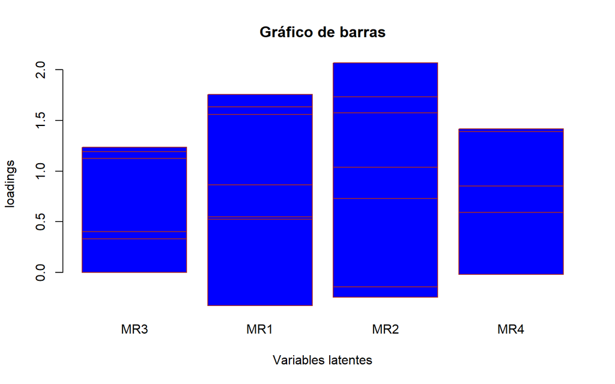

```r
barplot(resfa$loadings,
        xlab = "Variables latentes",
        ylab = "loadings",
        main = "Gráfico de barras",
        col = "blue",
        border = "brown")
```

INTERPRETACIÓN:

```r
as.data.frame(resfa$scores)%>%head()
```

```
##           MR3         MR1        MR2        MR4
## 1   0.1495129 -0.36431236  0.6939209 -0.4695234
## 2   1.0436118 -0.21058983 -0.2451836 -0.3147414
## 4   2.0478090  0.26313213 -3.1966809  0.2095266
## 7   0.1942550 -0.29383511  0.2871555 -0.6183329
## 8   0.3994703 -0.08514776  0.8877091  0.7888678
## 12 -0.1662390 -0.32127651  0.2353869  3.3610864
```

**Conclusión. Concluya sobre los resultados obtenidos.**

En sintesis, el analisis factorial exploratorio nos permite agrupar todas nuestras variables en 4 variables latentes que permitan explicar de mejor manera la dependencIa con la pobreza en los servicios básicos en las provincias del Perú.

# Conclusión general:

En resumen, debido a los resultados obtenidos tanto en nuestro analisis de regresión lineal y analisis factorial podemos concluir: en primer lugar, el modelo realizado para explicar la relación de nuestra variabale dependiente en función de las variables independientes que son los servicios básicos brindan una explicanción de 25.61 %. En segundo lugar, gracias al analisis factorial podemos ver que este conjunto de variaables se pueden agrupar en factores principales que nos permitan entender de mejor manera la dependecia de la pobreza en los servicios básicos en las pronvincias del Perú. De esta manera a traves de los resultados concretos obetenidos podemos concluir que la pobreza tiende a variar en relación de cuánto acceso a servicios báscios esenciales pone a disposición nuestro país. Entender esto nos permitirá enfocar los procesos de solución de mejor manera y combatir este problema social que no solo se vive en nuestro país, sino en el mmundo.